# Plasmid Assembly at the AGRF

Alexis Lucattini  
July, 2017

### What can you hope to get out of this talk

- Nanopore expectations with low input.
- What plasmids are and why they are useful.
- Applied examples of bioinformatic tools for Nanopore sequencing.
- Potential AGRF partnership with Nanopore sequencing.

#### List of tools used during this talk.

| Name | Author | Focus |
| --- | --- | --- |
| Poreduck | A. Lucattini | Data Handling |
| Albacore | ONT | Basecalling |
| Porechop | R. Wick | Trimming |
| Pauvre | D. Schultz | QC-plotting |
| Canu | S. Koren | Assembly |
| Circlator | M. Hunt | Assembly |

### Plasmid Background

- Plasmids are small circular dsDNA sequences, found mainly in bacteria.
- Bacteria can use plasmids to share genetic information, even between different species.
- Genes on plasmids can encode for virulence factors or anti-microbial resistance.
- But scientists can also use plasmids to clone, transfer or manipulate genes

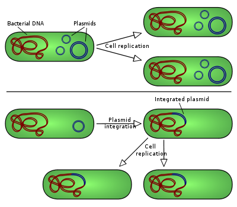

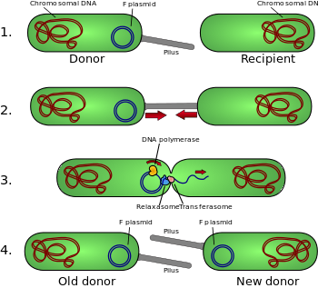

### Traditional Plasmid Sequencing at the AGRF

- Samples sequenced on MiSeq or Sanger.
- Sanger with multiple primers to 'hop' through genome
- MiSeq, huge coverage yet poor assembly.
- Potential market for plasmid length MinION reads.

### Nanopore Yields:

### You only get out, what you put in (Nutri-grain et al.)

- High molecular weight DNA ( > 1µg) ==> High yields 5-10+ Gbs.
- Low yields in plasmid extraction, sequencing used as confirmation.
- But how low can one go and still achieve their desired outcome?
  - 500 ng?
  - … 50 ng?

### 8 plasmids: 4 bigs, 4 smalls

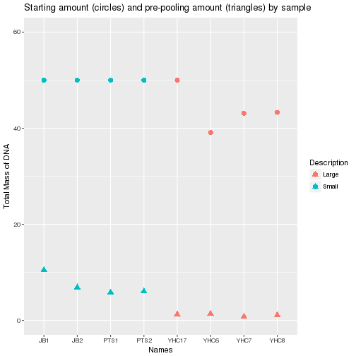

- Small plasmids retained through clean-ups better than large plasmids.
- Reasons unknown.
  - Higher quality DNA?
  - Smaller DNA less likely to break?
- Protocol instructs normalise to 700 ng?
- We have a small dilemma…

### A handy workaround.

### The problem

- Highly unbalanced library.
- Can obtain equal sequencing by lowering all inputs
  - Only as good as your lowest yield.

### The solution

- Add the good samples once the bad samples have had a go…
- Can use real-time analysis to know when to add.

### The real-time analysis pipeline. Part 1/6

[figure not shown]

Find me on Github. www.github.com/alexiswl/poreduck

Two main scripts:

- Transfer data to server and remove from laptop.
- Run albacore through SGE on server.

Both scripts run in real-time.

#### Basic steps of Poreduck pipeline.

- transfer script zips up full read folders and uses Rsync to move folder to server.
- transfer script continues to run until MinKNOW has finished.
- albacore script will unzip and run through basecaller. Outputs a fastq file for each folder. Barcoding compatible.
- This run shows need for low-yield parameter. Zip every 100 fast5 files.

### The real-time analysis pipeline. Part 2/6

[figure not shown]

- Removes both ligation and barcoding adapters from nanopore reads.
- Can also quality filter reads with 'unusual results'.
- Useful output summary.

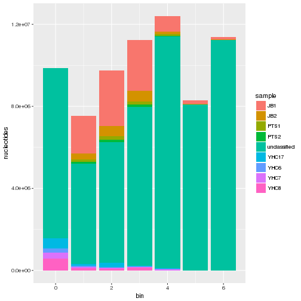

### The real-time analysis pipeline. Part 2/6

#### Road block:

- Large amount of unclassified reads.
- Potential library step issue.
  - DNA extraction?
  - End-prep issue?
- Could still use for consensus?

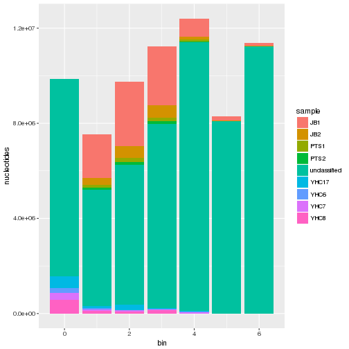

### The real-time analysis pipeline. Part 3/6

| Sample | Yield |
| --- | --- |
| JB1 | 8073511 |
| JB2 | 1475418 |
| PTS1 | 549940 |
| PTS2 | 324648 |
| unclassified | 57426941 |
| YHC17 | 871441 |
| YHC6 | 363154 |
| YHC7 | 468044 |
| YHC8 | 903629 |

Lowest sample yield is 324648 bp for sample PTS2

### The real-time analysis pipeline. Part 3/6

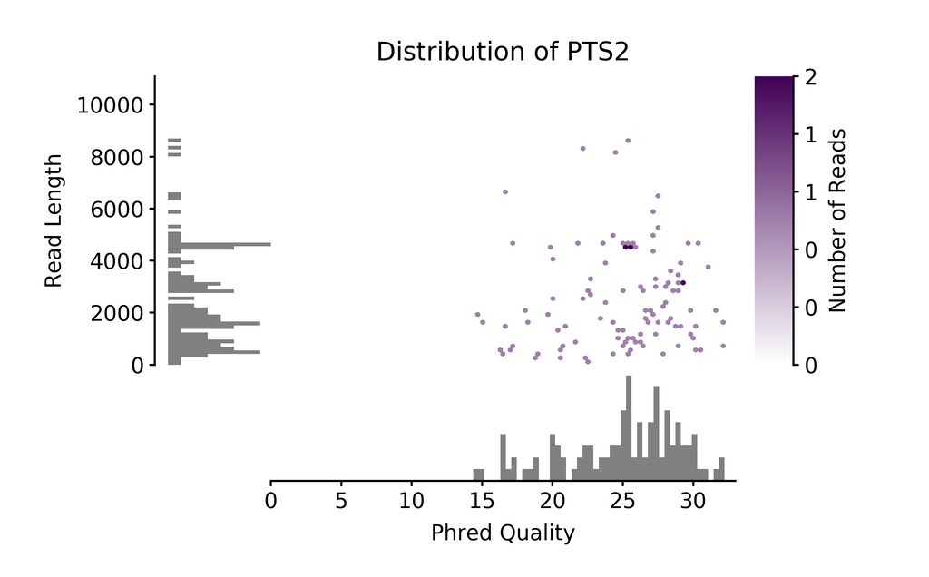

### The real-time analysis pipeline. Part 4/6

### Assembly with Canu

- Now we have our genome length parameter let the assembly begin.

#### Example Canu assembly command

```bash
canu -d assemblies/barcode06/ -p YHC6 genomeSize=18k \
-nanopore-raw
```

canu can also invoke your SGE.  
See the docs http://canu.readthedocs.io/en/latest/

### The real-time analysis pipeline. Part 5/6

### Use circulator to cut edges that may have exceeded.

Using circulator minimus2 we can circularise the assembly

```bash
circilator minimus2 <input.fasta> <output.prefix>
```

### The real-time analysis pipeline. Part 6/6

### Realign to our circuarlised draft genome.

- Using samtools we can realign our trimmed reads to our draft genome.
- View alignment with IGV.
- Does everything look right?

### The validation process. Circularisation

- Circulariser logs. `circle_dir/sample.log`
  - Did the genome circularise?
  - Good indication of assembly process.

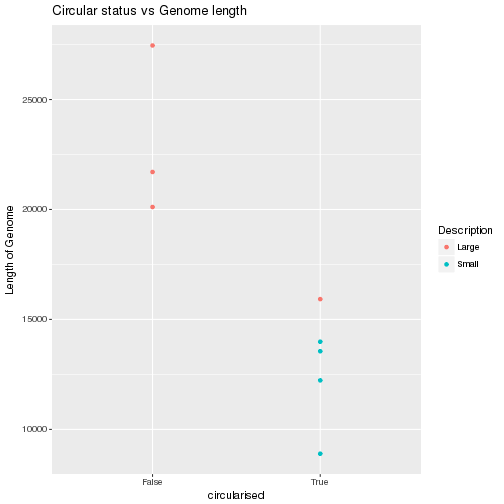

### The validation process. Circularised Genome

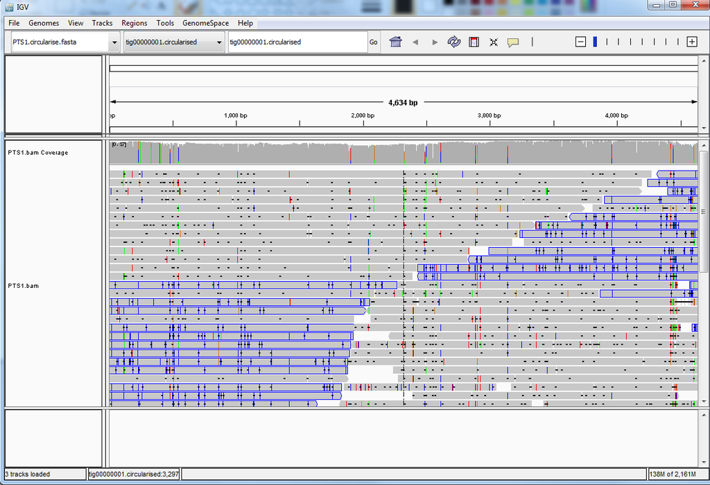

### The validation process. Non-circularised Genome

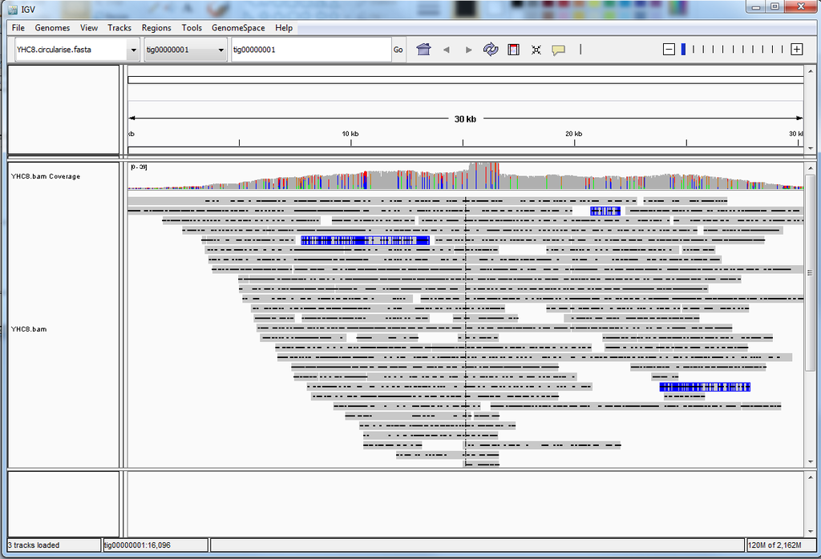

### What about all the unclassified data?

- In this particular run there was a large amount of unclassified data.
- Can we map it to our draft genomes for a greater consensus sequence?

### With the help of hybrid assemblies:

- Unicycler.